# Predicting American Airline Flight Delays in United States

Bruce Zhang, Jaime Andaluz, Frazil Mustapa, Isha Singh

## Introduction

This project is done by a group of INSEAD MBA(17J) students who are enrolled in the Big Data and Analytics for Business elective conducted by Prof Theos Evgeniou in 2017 Jan. We use several statistical analysis models learned in the class to analyze a new dataset about US deomestic flight delay in 2008, with the aim to find out the main causes for flight delay in general and provide a statistical guideline to minimize flight delay in US. The work is written in R programming language.

## Project Description

Flight delays are a key factor for airline profitability, since it decreases the utilization of the assets, decreases negotiation power with airports, and create a bad perception on customers.

We aim to have a deep understanding of the causes of the flight delay from a statistical approach. Based on the data we gather for American Airline flight delay in 2008 Jan, we will perform factor analysis to find out the reasons of the delay and try to develop a predictive model to predict future flight delay.

## Explaining the data

This is how the first 15 data looks:

|  | DepTime | CRSDepTime | ArrTime | CRSArrTime | ActualElapsedTime | CRSElapsedTime | AirTime | ArrDelay | DepDelay | Origin | Dest | Distance | TaxiIn | TaxiOut | CarrierDelay | WeatherDelay | NASDelay | SecurityDelay | LateAircraftDelay |
| --- | --- | --- | --- | --- | --- | --- | --- | --- | --- | --- | --- | --- | --- | --- | --- | --- | --- | --- | --- |
| 01 | 1909 | 1900 | 2256 | 2230 | 407 | 390 | 333 | 26 | 9 | 33 | 36 | 2475 | 33 | 41 | 9 | 0 | 17 | 0 | 0 |
| 02 | 847 | 810 | 1252 | 1155 | 365 | 345 | 339 | 57 | 37 | 36 | 25 | 2556 | 7 | 19 | 37 | 0 | 20 | 0 | 0 |
| 03 | 1741 | 1705 | 2000 | 1935 | 139 | 150 | 106 | 25 | 36 | 52 | 16 | 802 | 6 | 27 | 0 | 25 | 0 | 0 | 0 |
| 04 | 942 | 905 | 1504 | 1425 | 562 | 560 | 538 | 39 | 37 | 52 | 25 | 4243 | 4 | 20 | 0 | 37 | 2 | 0 | 0 |
| 05 | 1358 | 1300 | 1613 | 1520 | 135 | 140 | 111 | 53 | 58 | 16 | 52 | 802 | 8 | 16 | 53 | 0 | 0 | 0 | 0 |
| 06 | 1231 | 920 | 2100 | 1740 | 329 | 320 | 289 | 200 | 191 | 36 | 20 | 2454 | 7 | 33 | 191 | 0 | 9 | 0 | 0 |
| 07 | 2217 | 1845 | 106 | 2200 | 349 | 375 | 323 | 186 | 212 | 20 | 36 | 2454 | 6 | 20 | 15 | 0 | 0 | 0 | 171 |
| 08 | 1757 | 1630 | 2109 | 1955 | 372 | 385 | 349 | 74 | 87 | 7 | 36 | 2611 | 6 | 17 | 2 | 0 | 0 | 0 | 72 |
| 09 | 2331 | 2325 | 812 | 750 | 341 | 325 | 319 | 22 | 6 | 67 | 7 | 2704 | 6 | 16 | 5 | 0 | 17 | 0 | 0 |
| 10 | 1758 | 1715 | 2119 | 2030 | 141 | 135 | 116 | 49 | 43 | 52 | 7 | 867 | 4 | 21 | 0 | 25 | 6 | 0 | 18 |
| 11 | 1719 | 1650 | 2115 | 2025 | 356 | 335 | 334 | 50 | 29 | 36 | 48 | 2486 | 5 | 17 | 0 | 0 | 24 | 0 | 26 |
| 12 | 1719 | 1520 | 116 | 2330 | 297 | 310 | 280 | 106 | 119 | 36 | 20 | 2454 | 5 | 12 | 104 | 0 | 0 | 0 | 2 |
| 13 | 1833 | 1615 | 242 | 25 | 309 | 310 | 288 | 137 | 138 | 36 | 33 | 2475 | 4 | 17 | 126 | 0 | 0 | 0 | 11 |
| 14 | 1523 | 1425 | 2336 | 2250 | 313 | 325 | 295 | 46 | 58 | 67 | 7 | 2704 | 6 | 12 | 46 | 0 | 0 | 0 | 0 |
| 15 | 829 | 705 | 1655 | 1525 | 326 | 320 | 300 | 90 | 84 | 36 | 7 | 2611 | 5 | 21 | 84 | 0 | 6 | 0 | 0 |

In January 2008, American Airline has 13032 number of demestic flight delays

[figure not shown]

[figure not shown]

|  | min | 25 percent | median | mean | 75 percent | max | std |
| --- | --- | --- | --- | --- | --- | --- | --- |
| DepTime | 2 | 1245 | 1619 | 1563.43 | 1922 | 2400 | 453.27 |
| CRSDepTime | 25 | 1205 | 1530 | 1493.72 | 1825 | 2355 | 414.65 |
| ArrTime | 1 | 1347 | 1801 | 1621.06 | 2105 | 2400 | 626.89 |
| CRSArrTime | 5 | 1415 | 1750 | 1686.50 | 2040 | 2359 | 476.19 |
| ActualElapsedTime | 33 | 127 | 168 | 176.28 | 214 | 583 | 73.47 |
| CRSElapsedTime | 40 | 130 | 165 | 172.30 | 205 | 560 | 70.20 |
| AirTime | 15 | 101 | 139 | 147.74 | 183 | 548 | 70.44 |
| ArrDelay | 15 | 27 | 47 | 65.87 | 83 | 1525 | 62.62 |
| DepDelay | 6 | 25 | 44 | 61.88 | 79 | 1355 | 61.12 |
| Origin | 1 | 16 | 37 | 36.83 | 52 | 79 | 20.07 |
| Dest | 1 | 16 | 39 | 38.57 | 52 | 79 | 20.80 |
| Distance | 68 | 719 | 1020 | 1075.58 | 1372 | 4243 | 570.18 |
| TaxiIn | 1 | 5 | 6 | 8.32 | 10 | 189 | 7.35 |
| TaxiOut | 1 | 12 | 16 | 20.23 | 22 | 224 | 14.36 |
| CarrierDelay | 0 | 0 | 2 | 18.39 | 21 | 1158 | 43.72 |
| WeatherDelay | 0 | 0 | 0 | 2.67 | 0 | 685 | 12.90 |
| NASDelay | 0 | 0 | 5 | 18.61 | 19 | 1357 | 38.73 |
| SecurityDelay | 0 | 0 | 0 | 0.05 | 0 | 41 | 1.01 |
| LateAircraftDelay | 0 | 0 | 11 | 26.15 | 35 | 447 | 39.41 |

## Scale the data

```r
ProjectDatafactor_scaled = apply(ProjectDataFactor, 2, function(r) {
    if (sd(r) != 0)
        res = (r - mean(r))/sd(r) else res = 0 * r
    res
})
```

Notice now the summary statistics of the scaled dataset:

|  | min | 25 percent | median | mean | 75 percent | max | std |
| --- | --- | --- | --- | --- | --- | --- | --- |
| DepTime | -3.44 | -0.70 | 0.12 | 0 | 0.79 | 1.85 | 1 |
| CRSDepTime | -3.54 | -0.70 | 0.09 | 0 | 0.80 | 2.08 | 1 |
| ArrTime | -2.58 | -0.44 | 0.29 | 0 | 0.77 | 1.24 | 1 |
| CRSArrTime | -3.53 | -0.57 | 0.13 | 0 | 0.74 | 1.41 | 1 |
| ActualElapsedTime | -1.95 | -0.67 | -0.11 | 0 | 0.51 | 5.54 | 1 |
| CRSElapsedTime | -1.88 | -0.60 | -0.10 | 0 | 0.47 | 5.52 | 1 |
| AirTime | -1.88 | -0.66 | -0.12 | 0 | 0.50 | 5.68 | 1 |
| ArrDelay | -0.81 | -0.62 | -0.30 | 0 | 0.27 | 23.30 | 1 |
| DepDelay | -0.91 | -0.60 | -0.29 | 0 | 0.28 | 21.16 | 1 |
| Origin | -1.79 | -1.04 | 0.01 | 0 | 0.76 | 2.10 | 1 |
| Dest | -1.81 | -1.09 | 0.02 | 0 | 0.65 | 1.94 | 1 |
| Distance | -1.77 | -0.63 | -0.10 | 0 | 0.52 | 5.56 | 1 |
| TaxiIn | -1.00 | -0.45 | -0.32 | 0 | 0.23 | 24.60 | 1 |
| TaxiOut | -1.34 | -0.57 | -0.29 | 0 | 0.12 | 14.19 | 1 |
| CarrierDelay | -0.42 | -0.42 | -0.37 | 0 | 0.06 | 26.07 | 1 |
| WeatherDelay | -0.21 | -0.21 | -0.21 | 0 | -0.21 | 52.89 | 1 |
| NASDelay | -0.48 | -0.48 | -0.35 | 0 | 0.01 | 34.56 | 1 |
| SecurityDelay | -0.05 | -0.05 | -0.05 | 0 | -0.05 | 40.72 | 1 |
| LateAircraftDelay | -0.66 | -0.66 | -0.38 | 0 | 0.22 | 10.68 | 1 |

As expected all variables have mean 0 and standard deviation 1.

## Check Correlations

|  | DepTime | CRSDepTime | ArrTime | CRSArrTime | ActualElapsedTime | CRSElapsedTime | AirTime | ArrDelay | DepDelay | Origin | Dest | Distance | TaxiIn | TaxiOut | CarrierDelay | WeatherDelay | NASDelay | SecurityDelay | LateAircraftDelay |
| --- | --- | --- | --- | --- | --- | --- | --- | --- | --- | --- | --- | --- | --- | --- | --- | --- | --- | --- | --- |
| DepTime | 1.00 | 0.81 | 0.19 | 0.59 | -0.09 | -0.08 | -0.09 | 0.12 | 0.14 | -0.04 | 0.03 | -0.10 | -0.02 | -0.03 | -0.03 | -0.03 | 0.01 | -0.02 | 0.22 |
| CRSDepTime | 0.81 | 1.00 | 0.10 | 0.55 | -0.06 | -0.05 | -0.05 | 0.05 | 0.07 | -0.05 | 0.02 | -0.05 | -0.02 | -0.06 | -0.06 | -0.03 | -0.05 | -0.02 | 0.21 |
| ArrTime | 0.19 | 0.10 | 1.00 | 0.43 | -0.02 | -0.03 | -0.04 | -0.06 | -0.07 | -0.03 | 0.04 | -0.06 | 0.04 | 0.06 | -0.10 | -0.03 | 0.09 | 0.01 | -0.06 |
| CRSArrTime | 0.59 | 0.55 | 0.43 | 1.00 | -0.02 | -0.01 | -0.02 | 0.06 | 0.08 | -0.01 | 0.06 | -0.03 | 0.04 | -0.02 | -0.07 | -0.01 | 0.02 | -0.01 | 0.17 |
| ActualElapsedTime | -0.09 | -0.06 | -0.02 | -0.02 | 1.00 | 0.96 | 0.98 | 0.10 | 0.01 | 0.07 | 0.12 | 0.93 | 0.15 | 0.25 | 0.04 | 0.01 | 0.19 | 0.03 | -0.09 |
| CRSElapsedTime | -0.08 | -0.05 | -0.03 | -0.01 | 0.96 | 1.00 | 0.99 | 0.04 | 0.03 | 0.08 | 0.09 | 0.98 | 0.06 | 0.07 | 0.06 | 0.00 | 0.06 | 0.03 | -0.07 |
| AirTime | -0.09 | -0.05 | -0.04 | -0.02 | 0.98 | 0.99 | 1.00 | 0.04 | 0.00 | 0.06 | 0.11 | 0.96 | 0.05 | 0.06 | 0.06 | 0.00 | 0.08 | 0.02 | -0.08 |
| ArrDelay | 0.12 | 0.05 | -0.06 | 0.06 | 0.10 | 0.04 | 0.04 | 1.00 | 0.95 | 0.11 | 0.07 | 0.04 | 0.07 | 0.24 | 0.53 | 0.15 | 0.47 | -0.02 | 0.50 |
| DepDelay | 0.14 | 0.07 | -0.07 | 0.08 | 0.01 | 0.03 | 0.00 | 0.95 | 1.00 | 0.12 | 0.04 | 0.04 | -0.03 | 0.02 | 0.56 | 0.14 | 0.31 | -0.02 | 0.54 |
| Origin | -0.04 | -0.05 | -0.03 | -0.01 | 0.07 | 0.08 | 0.06 | 0.11 | 0.12 | 1.00 | -0.05 | 0.09 | 0.06 | 0.01 | -0.03 | 0.05 | 0.05 | 0.00 | 0.14 |
| Dest | 0.03 | 0.02 | 0.04 | 0.06 | 0.12 | 0.09 | 0.11 | 0.07 | 0.04 | -0.05 | 1.00 | 0.09 | -0.11 | 0.10 | -0.01 | 0.00 | 0.16 | -0.02 | -0.04 |
| Distance | -0.10 | -0.05 | -0.06 | -0.03 | 0.93 | 0.98 | 0.96 | 0.04 | 0.04 | 0.09 | 0.09 | 1.00 | 0.04 | 0.03 | 0.08 | 0.00 | 0.03 | 0.02 | -0.06 |
| TaxiIn | -0.02 | -0.02 | 0.04 | 0.04 | 0.15 | 0.06 | 0.05 | 0.07 | -0.03 | 0.06 | -0.11 | 0.04 | 1.00 | 0.03 | -0.05 | -0.02 | 0.18 | 0.01 | 0.00 |
| TaxiOut | -0.03 | -0.06 | 0.06 | -0.02 | 0.25 | 0.07 | 0.06 | 0.24 | 0.02 | 0.01 | 0.10 | 0.03 | 0.03 | 1.00 | -0.06 | 0.04 | 0.48 | 0.01 | -0.04 |
| CarrierDelay | -0.03 | -0.06 | -0.10 | -0.07 | 0.04 | 0.06 | 0.06 | 0.53 | 0.56 | -0.03 | -0.01 | 0.08 | -0.05 | -0.06 | 1.00 | -0.06 | -0.13 | -0.02 | -0.12 |
| WeatherDelay | -0.03 | -0.03 | -0.03 | -0.01 | 0.01 | 0.00 | 0.00 | 0.15 | 0.14 | 0.05 | 0.00 | 0.00 | -0.02 | 0.04 | -0.06 | 1.00 | -0.04 | -0.01 | 0.01 |
| NASDelay | 0.01 | -0.05 | 0.09 | 0.02 | 0.19 | 0.06 | 0.08 | 0.47 | 0.31 | 0.05 | 0.16 | 0.03 | 0.18 | 0.48 | -0.13 | -0.04 | 1.00 | -0.01 | -0.08 |
| SecurityDelay | -0.02 | -0.02 | 0.01 | -0.01 | 0.03 | 0.03 | 0.02 | -0.02 | -0.02 | 0.00 | -0.02 | 0.02 | 0.01 | 0.01 | -0.02 | -0.01 | -0.01 | 1.00 | -0.02 |
| LateAircraftDelay | 0.22 | 0.21 | -0.06 | 0.17 | -0.09 | -0.07 | -0.08 | 0.50 | 0.54 | 0.14 | -0.04 | -0.06 | 0.00 | -0.04 | -0.12 | 0.01 | -0.08 | -0.02 | 1.00 |

## Principle Components Analysis

|  | Eigenvalue | Pct of explained variance | Cumulative pct of explained variance |
| --- | --- | --- | --- |
| Component 1 | 4.02 | 21.18 | 21.18 |
| Component 2 | 2.89 | 15.23 | 36.41 |
| Component 3 | 2.34 | 12.32 | 48.73 |
| Component 4 | 1.65 | 8.69 | 57.42 |
| Component 5 | 1.24 | 6.55 | 63.97 |
| Component 6 | 1.10 | 5.77 | 69.74 |
| Component 7 | 1.00 | 5.27 | 75.01 |
| Component 8 | 1.00 | 5.24 | 80.25 |
| Component 9 | 0.94 | 4.93 | 85.18 |
| Component 10 | 0.83 | 4.37 | 89.55 |
| Component 11 | 0.81 | 4.28 | 93.83 |
| Component 12 | 0.55 | 2.88 | 96.71 |
| Component 13 | 0.37 | 1.94 | 98.65 |
| Component 14 | 0.18 | 0.93 | 99.58 |
| Component 15 | 0.06 | 0.30 | 99.88 |
| Component 16 | 0.02 | 0.12 | 100.00 |
| Component 17 | 0.00 | 0.00 | 100.00 |
| Component 18 | 0.00 | 0.00 | 100.00 |
| Component 19 | 0.00 | 0.00 | 100.00 |

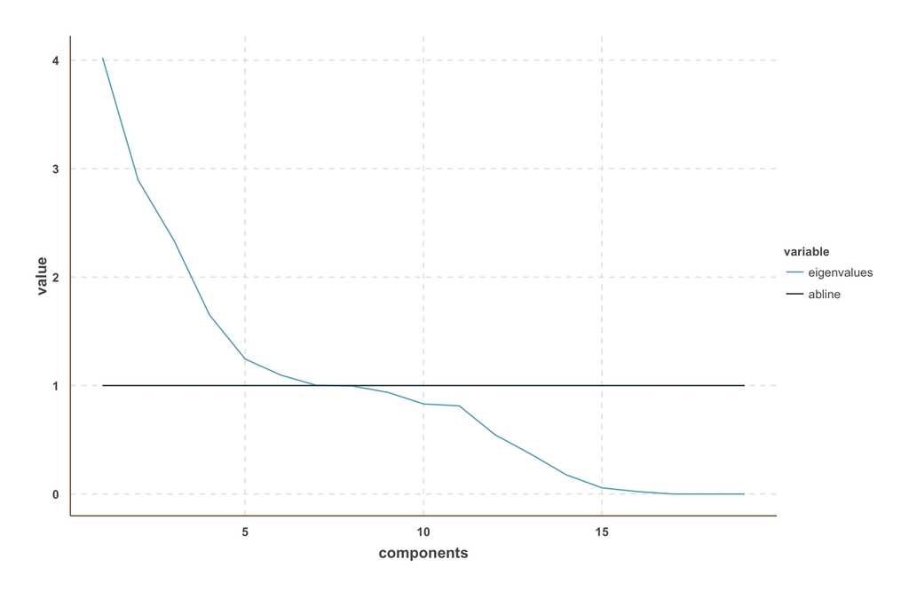